# Pooled zero-dose estimates: SME + DHIS2

- Show All Code
- Hide All Code
- View Source

# Pooling with DHIS2 administrative data: counts and comparison maps

Self-contained: uses `combined`, `adm3_sum`, `adm1_ocha`, `theme_map`, and `save_map` if they already exist in your session (e.g. pasted into the main pipeline after “Stage 2 maps”), otherwise loads/builds them from disk so this file also renders standalone with `quarto preview pooled_zero_dose_mapping_section.qmd`.

**Edit the paths in `setup-pooled` to match your project** - the four you need are the SME csv, the two DHIS2 workbooks, and (only if `adm3_sum` / `adm1_ocha` don’t already exist in your session) the admin-3 shapefile and admin-1 boundary file.

```r
suppressMessages({
  library(readxl); library(dplyr); library(stringr); library(stringdist)
  library(tidyr); library(readr); library(sf); library(ggplot2); library(scales)
})

## ---- 1. Paths (EDIT THESE to match your project) -----------------------------
sme_path        <- "data/final_two_stage_estimates.csv"
dhis2_new_path  <- "data/Zero_dose DHIS2 prevalence.xlsx"   # BoFED + DHIS2 names
dhis2_old_path  <- "data/Penta_updated33_for_modeling.xlsx" # used only to recover Region

## only used if adm3_sum / adm1_ocha aren't already in your session
path_adm3_shp   <- "data/raw/eth_admin_boundaries.shp/eth_admin3.shp"
path_adm1_ocha  <- "data/raw/eth_admin_boundaries.shp/eth_admin1.shp"

out_final <- "data/clean/merged_dhis2_final.csv"
dir.create(dirname(out_final), showWarnings = FALSE, recursive = TRUE)

FUZZY_THRESHOLD <- 0.90  # Jaro-Winkler similarity for the fuzzy passes

## ---- 2. Bring in combined / adm3_sum / adm1_ocha / theme_map / save_map ------
## Re-use them if this chunk is running inside the main pipeline session;
## otherwise build/load them here so the file also renders on its own.
if (!exists("combined")) {
  message("`combined` not found in session -> reading from ", sme_path)
  combined <- read_csv(sme_path, show_col_types = FALSE)
}

if (!exists("adm3_sum")) {
  message("`adm3_sum` not found in session -> reading shapefile from ", path_adm3_shp)
  adm3_sum <- read_sf(path_adm3_shp) %>%
    transmute(woreda_id = adm3_pcode)
}

if (!exists("adm1_ocha")) {
  message("`adm1_ocha` not found in session -> reading from ", path_adm1_ocha)
  adm1_ocha <- read_sf(path_adm1_ocha)
}

if (!exists("theme_map")) {
  theme_map <- theme_void(base_size = 11) +
    theme(plot.title = element_text(face = "bold", hjust = 0.5, size = 13),
          plot.subtitle = element_text(hjust = 0.5, size = 10, colour = "grey30"),
          legend.position = "bottom",
          legend.direction = "horizontal",
          legend.key.width = unit(1.4, "cm"),
          legend.title = element_text(size = 9, vjust = 0.8),
          plot.caption = element_text(size = 8, colour = "grey40"))
}

if (!exists("save_map")) {
  dir.create("data/clean/pipeline/maps", showWarnings = FALSE, recursive = TRUE)
  save_map <- function(p, f, w = 9, h = 8)
    ggsave(file.path("data/clean/pipeline/maps", f), p,
           width = w, height = h, dpi = 300, bg = "white")
}
```

We match DHIS2 rows to your 1148-woreda SAE frame using **two** name candidates per DHIS2 row - the BoFED name (`ADM3_EN_Bofed`, which tends to match your SME frame’s own naming convention) and the DHIS2 name (`Woreda_DHIS2`, the fallback). A BoFED name that repeats within the same zone is flagged unreliable (broken fill-down in the source file) and skipped in favour of the DHIS2 name for that row. Region isn’t in the new DHIS2 file, so it’s recovered via a bridge join against the old Penta workbook, which shares the same Zone/Woreda naming.

```r
sme <- read.csv(sme_path, stringsAsFactors = FALSE)

dhis2_new <- read_excel(dhis2_new_path, sheet = "Sheet1") %>%
  rename(
    zone_d    = Zone_DHIS2,
    bofed_d   = ADM3_EN_Bofed,
    woreda_d  = Woreda_DHIS2,
    lon_d     = Longitd,
    lat_d     = Latitud,
    penta1    = `Penta1_2025`,           # numerator; header is oddly just the year in your file
    SI        = SI_2025,
    coverage  = `Coverage 2025`,
    zero_dose_admin_raw = `zero dose prevalence`) %>%
  mutate(row_id_dhis2 = row_number())

dhis2_old <- read_excel(dhis2_old_path, sheet = "Sheet1") %>%
  rename(region_old = Region, zone_old = Zone, woreda_old = Woreda)

clean_name <- function(x) {
  x <- tolower(as.character(x))
  x <- str_replace_all(x, "[\\/\\-\\(\\)]", " ")
  drop_words <- c(
    "woreda", "wereda", "zone", "region", "regional health bureau",
    "city administration", "sub city", "subcity", "administration",
    "special", "town", "city admin", "city", "kentiba", "health office",
    "health department"
  )
  for (w in drop_words) x <- str_replace_all(x, fixed(w), " ")
  str_squish(x)
}

normalize_region <- function(x) {
  x <- clean_name(x)
  case_when(
    str_detect(x, "gambel")                ~ "gambela",
    str_detect(x, "benishangul")           ~ "benishangul-gumuz",
    str_detect(x, "central ethiop")        ~ "central ethiopia",
    str_detect(x, "south west")            ~ "south west ethiopia",
    str_detect(x, "^south ethiop")         ~ "south ethiopia",
    str_detect(x, "dire dawa")             ~ "dire dawa",
    str_detect(x, "addis ababa")           ~ "addis ababa",
    TRUE                                   ~ x
  )
}

## Bridge new file -> old file to recover Region (both use DHIS2 naming, so
## this is a clean, high-confidence exact join)
dhis2_new <- dhis2_new %>%
  mutate(zone_clean_dhis2 = clean_name(zone_d), woreda_clean_dhis2 = clean_name(woreda_d))

old_key <- dhis2_old %>%
  mutate(zone_clean_dhis2 = clean_name(zone_old), woreda_clean_dhis2 = clean_name(woreda_old)) %>%
  select(zone_clean_dhis2, woreda_clean_dhis2, region_old) %>%
  distinct(zone_clean_dhis2, woreda_clean_dhis2, .keep_all = TRUE)

dhis2_new <- dhis2_new %>%
  left_join(old_key, by = c("zone_clean_dhis2", "woreda_clean_dhis2")) %>%
  mutate(region_clean = normalize_region(region_old))

n_no_region <- sum(is.na(dhis2_new$region_clean))
message("DHIS2 rows where Region could not be recovered via the bridge: ",
        n_no_region, " / ", nrow(dhis2_new))

## Flag BoFED-name reliability: unreliable if it repeats within its zone
dhis2_new <- dhis2_new %>%
  mutate(bofed_clean = clean_name(bofed_d)) %>%
  group_by(zone_clean_dhis2, bofed_clean) %>%
  mutate(bofed_reliable = n() == 1 & !is.na(bofed_clean) & bofed_clean != "") %>%
  ungroup()

message("DHIS2 rows with a trustworthy (non-repeated) BoFED name: ",
        sum(dhis2_new$bofed_reliable), " / ", nrow(dhis2_new))

sme <- sme %>%
  mutate(row_id_sme = row_number(),
         region_clean = normalize_region(region),
         woreda_clean = clean_name(woreda))

sort_words <- function(s) paste(sort(str_split(s, " ")[[1]]), collapse = " ")

## try_pool(): exact match; if none, fuzzy match with a margin check so we
## don't silently pick an arbitrary winner among several close candidates.
try_pool <- function(wname, cand_names, cand_ids, tag) {
  if (length(cand_names) == 0) return(NULL)

  exact_idx <- which(cand_names == wname)
  if (length(exact_idx) == 1) {
    return(list(row_id_dhis2 = cand_ids[exact_idx], match_type = paste0(tag, "_exact"), similarity = 1))
  }
  if (length(exact_idx) > 1) {
    return(list(row_id_dhis2 = cand_ids[exact_idx[1]],
                match_type = paste0(tag, "_ambiguous_exact"), similarity = 1))
  }

  wname_sorted <- sort_words(wname)
  cand_sorted  <- vapply(cand_names, sort_words, character(1))
  sims <- stringsim(wname_sorted, cand_sorted, method = "jw", p = 0.1)
  best_idx <- which.max(sims); best_sim <- sims[best_idx]
  sims_sorted <- sort(sims, decreasing = TRUE)
  margin_ok <- length(sims_sorted) < 2 || (sims_sorted[1] - sims_sorted[2] > 0.03)

  if (best_sim >= FUZZY_THRESHOLD && margin_ok) {
    return(list(row_id_dhis2 = cand_ids[best_idx], match_type = paste0(tag, "_fuzzy"), similarity = best_sim))
  }
  if (best_sim >= FUZZY_THRESHOLD && !margin_ok) {
    return(list(row_id_dhis2 = cand_ids[best_idx],
                match_type = paste0(tag, "_ambiguous_fuzzy"), similarity = best_sim))
  }
  NULL
}

match_records <- vector("list", nrow(sme))
for (i in seq_len(nrow(sme))) {
  reg   <- sme$region_clean[i]
  wname <- sme$woreda_clean[i]
  pool  <- dhis2_new %>% filter(region_clean == reg)

  if (nrow(pool) == 0) {
    match_records[[i]] <- data.frame(row_id_sme = sme$row_id_sme[i], row_id_dhis2 = NA_integer_,
                                      match_type = "unmatched_no_region", similarity = NA_real_)
    next
  }

  rel_pool <- pool %>% filter(bofed_reliable)
  res <- try_pool(wname, rel_pool$bofed_clean, rel_pool$row_id_dhis2, "bofed")
  if (is.null(res)) res <- try_pool(wname, pool$woreda_clean_dhis2, pool$row_id_dhis2, "dhis2name")

  if (is.null(res)) {
    match_records[[i]] <- data.frame(row_id_sme = sme$row_id_sme[i], row_id_dhis2 = NA_integer_,
                                      match_type = "unmatched_no_similar_name", similarity = NA_real_)
  } else {
    match_records[[i]] <- data.frame(row_id_sme = sme$row_id_sme[i], row_id_dhis2 = res$row_id_dhis2,
                                      match_type = res$match_type, similarity = res$similarity)
  }
}
crosswalk <- bind_rows(match_records)

message("--- Matching summary ---")
print(table(crosswalk$match_type))
```

```
    bofed_ambiguous_exact     bofed_ambiguous_fuzzy               bofed_exact
                       18                         1                       658
              bofed_fuzzy dhis2name_ambiguous_exact dhis2name_ambiguous_fuzzy
                       31                        21                         8
          dhis2name_exact           dhis2name_fuzzy       unmatched_no_region
                      151                        64                        18
unmatched_no_similar_name
                      178
```

```r
message("Total SME woredas: ", nrow(sme))
```

```r
dhis2_small <- dhis2_new %>%
  select(row_id_dhis2, zone_d, bofed_d, woreda_d, lon_d, lat_d,
         penta1, SI, coverage, zero_dose_admin_raw)

merged <- sme %>%
  left_join(crosswalk, by = "row_id_sme") %>%
  left_join(dhis2_small, by = "row_id_dhis2") %>%
  mutate(
    zero_dose_prev_dhis2 = ifelse(is.na(zero_dose_admin_raw), NA_real_,
                                   pmax(zero_dose_admin_raw, 0)),   # defensive re-clip
    zero_dose_count_sme   = ifelse(!is.na(SI), final_estimate * SI, NA_real_),
    zero_dose_count_dhis2 = ifelse(!is.na(SI), zero_dose_prev_dhis2 * SI, NA_real_),
    pooled_zero_dose_prev = rowMeans(cbind(final_estimate, zero_dose_prev_dhis2), na.rm = TRUE),
    pooled_zero_dose_count = ifelse(!is.na(SI), pooled_zero_dose_prev * SI, NA_real_),
    matched_to_dhis2 = !is.na(row_id_dhis2)
  )

## `pooled_out` is the table the map chunks below join to `adm3_sum` - keep
## `final_estimate` under its own name too (`sme_zero_dose_prev`) but also
## keep the original column so both naming styles work.
pooled_out <- merged %>%
  select(
    woreda_id, region, zone, woreda,
    sme_zero_dose_prev = final_estimate,
    sme_lo = final_lo, sme_hi = final_hi,
    reliability, estimate_source,
    matched_to_dhis2, match_type, match_similarity = similarity,
    dhis2_zone = zone_d, dhis2_bofed_name = bofed_d, dhis2_woreda_name = woreda_d,
    penta1, SI, coverage,
    dhis2_zero_dose_prev = zero_dose_prev_dhis2,
    zero_dose_count_sme, zero_dose_count_dhis2,
    pooled_zero_dose_prev, pooled_zero_dose_count
  )

write.csv(pooled_out, out_final, row.names = FALSE, na = "")
message("Woredas with a usable SI (count computed): ", sum(!is.na(pooled_out$SI)),
        " / ", nrow(pooled_out))
```

## Maps

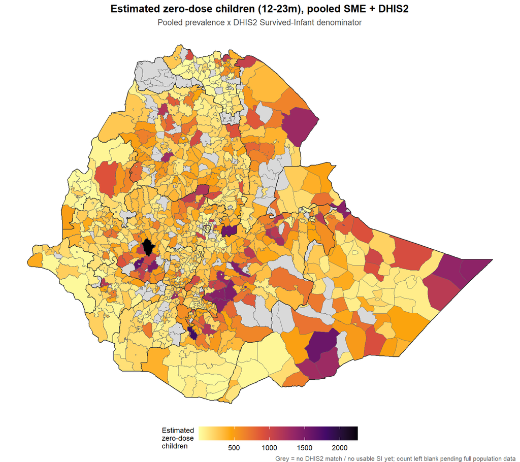

```r
map_sf_pooled <- adm3_sum %>% select(woreda_id) %>% left_join(pooled_out, by = "woreda_id")

p10 <- ggplot(map_sf_pooled) +
  geom_sf(aes(fill = pooled_zero_dose_count), colour = "grey40", linewidth = 0.08) +
  geom_sf(data = adm1_ocha, fill = NA, colour = "grey20", linewidth = 0.45) +
  scale_fill_viridis_c(option = "inferno", direction = -1, na.value = "grey85",
                       name = "Estimated\nzero-dose\nchildren") +
  labs(title = "Estimated zero-dose children (12-23m), pooled SME + DHIS2",
       subtitle = "Pooled prevalence x DHIS2 Survived-Infant denominator",
       caption = "Grey = no DHIS2 match / no usable SI yet; count left blank pending full population data") +
  theme_map
save_map(p10, "map_pooled_zero_dose_count.png")
p10
```

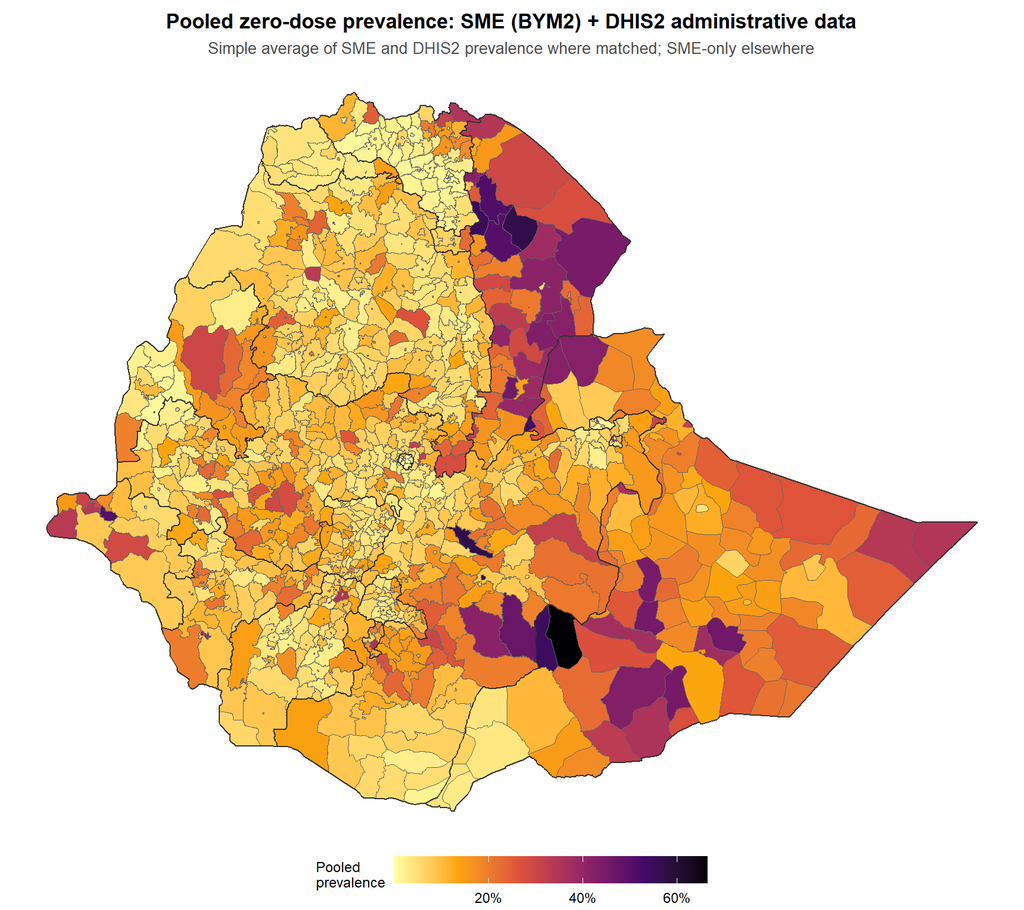

```r
p11 <- ggplot(map_sf_pooled) +
  geom_sf(aes(fill = pooled_zero_dose_prev), colour = "grey40", linewidth = 0.08) +
  geom_sf(data = adm1_ocha, fill = NA, colour = "grey20", linewidth = 0.45) +
  scale_fill_viridis_c(option = "inferno", direction = -1,
                       labels = percent_format(accuracy = 1), name = "Pooled\nprevalence") +
  labs(title = "Pooled zero-dose prevalence: SME (BYM2) + DHIS2 administrative data",
       subtitle = "Simple average of SME and DHIS2 prevalence where matched; SME-only elsewhere") +
  theme_map
save_map(p11, "map_pooled_prevalence.png")
p11
```

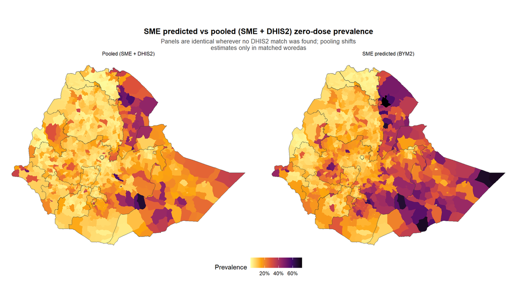

```r
comp_df2 <- bind_rows(
  map_sf_pooled %>% mutate(val = sme_zero_dose_prev,    panel = "SME predicted (BYM2)"),
  map_sf_pooled %>% mutate(val = pooled_zero_dose_prev, panel = "Pooled (SME + DHIS2)"))

p12 <- ggplot(comp_df2) +
  geom_sf(aes(fill = val), colour = NA) +
  geom_sf(data = adm1_ocha, fill = NA, colour = "grey20", linewidth = 0.3) +
  facet_wrap(~panel) +
  scale_fill_viridis_c(option = "inferno", direction = -1,
                       labels = percent_format(accuracy = 1), name = "Prevalence") +
  labs(title = "SME predicted vs pooled (SME + DHIS2) zero-dose prevalence",
       subtitle = "Panels are identical wherever no DHIS2 match was found; pooling shifts\nestimates only in matched woredas") +
  theme_void(base_size = 11) +
  theme(plot.title = element_text(face = "bold", hjust = 0.5, size = 13),
        plot.subtitle = element_text(hjust = 0.5, size = 10, colour = "grey30"),
        legend.position = "bottom")
save_map(p12, "map_predicted_vs_pooled.png", w = 12, h = 7)
p12
```